# Reproducible Research: Peer Assessment 1

## Loading and preprocessing the data.

### First unzip activity.zip file and do some basic data exploration.

```r
unzip("activity.zip")
library(dplyr)
library(lattice)
data=read.csv2("activity.csv",sep=",",header=TRUE)
head(data)
```

```
##   steps       date interval
## 1    NA 2012-10-01        0
## 2    NA 2012-10-01        5
## 3    NA 2012-10-01       10
## 4    NA 2012-10-01       15
## 5    NA 2012-10-01       20
## 6    NA 2012-10-01       25
```

```r
names(data)
```

```
## [1] "steps"    "date"     "interval"
```

```r
dim(data)
```

```
## [1] 17568     3
```

## What is mean and median total number of steps taken per day?

#### For this part of the assignment, you can ignore the missing values in the dataset. Make a histogram of the total number of steps taken each day.Calculate and report the mean and median total number of steps taken per day

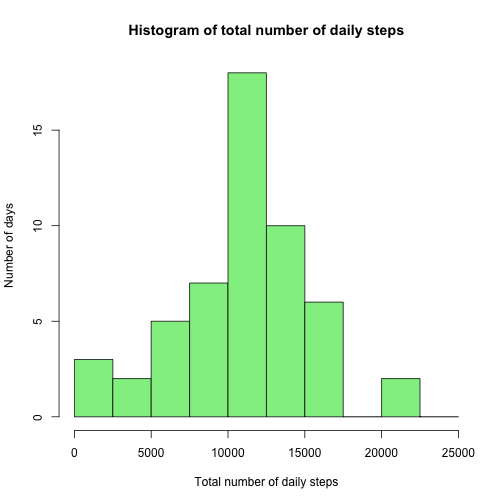

```r
daily_step_totals=sapply(split(data$steps,data$date),sum)
hist(daily_step_totals,breaks=c(seq(0,25000,2500)),xlab="Total number of daily steps",ylab="Number of days",main="Histogram of total number of daily steps",col="lightgreen")
```

```r
mean_daily_steps=mean(daily_step_totals,na.rm=TRUE)
median_daily_steps=median(daily_step_totals,na.rm=TRUE)
cat(paste("Mean Daily Steps:", mean_daily_steps ))
```

Mean Daily Steps: 10766.1886792453

```r
cat(paste("Median Daily Steps:", median_daily_steps ))
```

Median Daily Steps: 10765

## What is the average daily activity pattern?

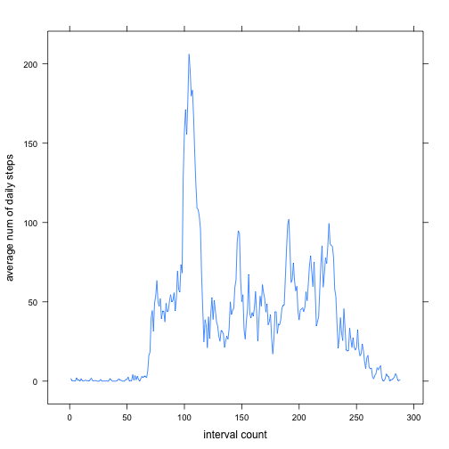

```r
avg_daily_pattern=sapply(split(data$steps,data$interval),mean,na.rm=TRUE)
aa=1:288
avg_daily_df=as.data.frame(cbind(aa,avg_daily_pattern))
names(avg_daily_df)=c("id","avg_daily_pattern")
xyplot(avg_daily_pattern ~ id, data =avg_daily_df ,  type = "l",xlab="interval count",ylab="average num of daily steps")
```

```r
hours=data$interval %/% 100
minutes=data$interval %% 60

avg_daily_pattern[avg_daily_pattern==max(avg_daily_pattern)]
```

```
##      835
## 206.1698
```

## Imputing missing values.

```r
tot_num_of_missing_values=sum(is.na(data))
cat(paste("Total number of missing values:",tot_num_of_missing_values  ))
```

Total number of missing values: 2304

#### Simplest case: Impute missing values with average for that interval.Do this using if else and select and regenerating a histogram for the new dataset.

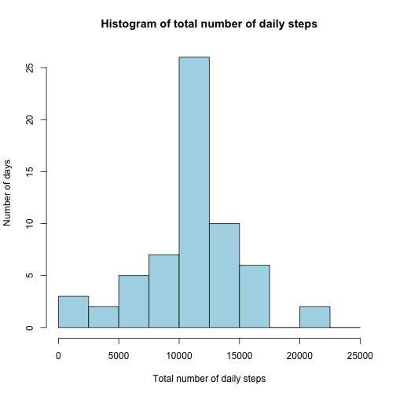

```r
means_vec=means_vec=as.vector(avg_daily_pattern)
int_vec= as.numeric(levels(as.factor(data$interval)) )
data$updated_steps=ifelse((is.na(data$steps)),means_vec[match(data$interval,int_vec)],data$steps)
updated_data=select(data,-steps)
aa=group_by(updated_data,date)
updated_stepsSum=summarize(aa,daily_tot=sum(updated_steps))
hist(updated_stepsSum$daily_tot,breaks=c(seq(0,25000,2500)),xlab="Total number of daily steps",ylab="Number of days",main="Histogram of total number of daily steps",col="lightblue")
```

```r
data=select(data,-steps)
imputed_mean_daily_steps=mean(updated_stepsSum$daily_tot,na.rm=TRUE)
imputed_median_daily_steps=median(updated_stepsSum$daily_tot,na.rm=TRUE)
cat(paste("Mean Daily Steps:", imputed_mean_daily_steps ))
```

Mean Daily Steps: 10766.1886792453

```r
cat(paste("Median Daily Steps:", imputed_median_daily_steps ))
```

Median Daily Steps: 10766.1886792453

#### There is no difference in the mean number of steps before and after imputing -which makes sense as I imputed the missing steps values with the average number of steps for that interval. There is a slight uptick in the median number of steps and now the median number of steps =mean number of daily steps.

## Are there differences in activity patterns between weekdays and weekends?

#### Note: we are using the data with imputed values. First get the days of the week and then get the factor in numeric form.

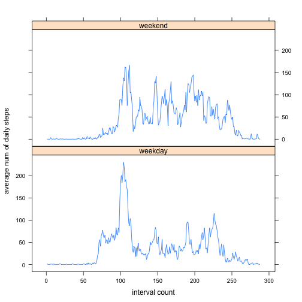

```r
#data$day=weekdays(as.Date(data$date))
data$day_numeric=as.POSIXlt(data$date)$wday
data=data %>% mutate(day_factor=ifelse(day_numeric==0 | day_numeric==6,1,2))
weekend_data=filter(data,day_factor==1)
weekday_data=filter(data,day_factor==2)
weekday_avg_daily_pattern=sapply(split(weekday_data$updated_steps,weekday_data$interval),mean,na.rm=TRUE)
weekend_avg_daily_pattern=sapply(split(weekend_data$updated_steps,weekend_data$interval),mean,na.rm=TRUE)
a=1:288
combine=as.data.frame(cbind(a,as.vector(weekday_avg_daily_pattern),as.vector(weekend_avg_daily_pattern)))
names(combine)=c("id","weekday","weekend")
xyplot(weekday + weekend ~ id, data = combine, layout = c(1,2), type = "l",xlab="interval count",ylab="average num of daily steps", outer = TRUE)
```